# N2analyses

Hannah, 3/31/17

**Major changes: Reknitted with new data (trials fixed for subs 2, 4, 8, 16, 17, 19, 30, 59, 70, 72. Also, 74 and 19 were missing before, are now included.**

“Current” trial will be included if:  
1) Current trial is not rejected due to artifacts.  
2) Current trial is not the first trial of the block (i.e. trial 1, 101, 201, 301 etc. are not included).  
3) Both current trial and previous trial are correct.

The following electrodes are included: F3, Fz, F4, FC3, FCz, FC4, C3, Cz, C4.

The following subjects were excluded:  
- 92 (wrong number of trials, possibly data collection error)  
- 64 (<50% accuracy rate)  
- 65 (only 187 usable trials (23.3%))

One or more electrodes were bad for subjects 19, 74, and 137 (data from those electrodes is discarded).

Besides that, ERP data is completely missing for subs 36, 37, 39, 40, 42, 43, 46, 51, 53, 54, 56, 57, 78.

**Total sample is 36 subjects.**

### 1. Grand averages, not looking at change over experiment

[output not shown]

[output not shown]

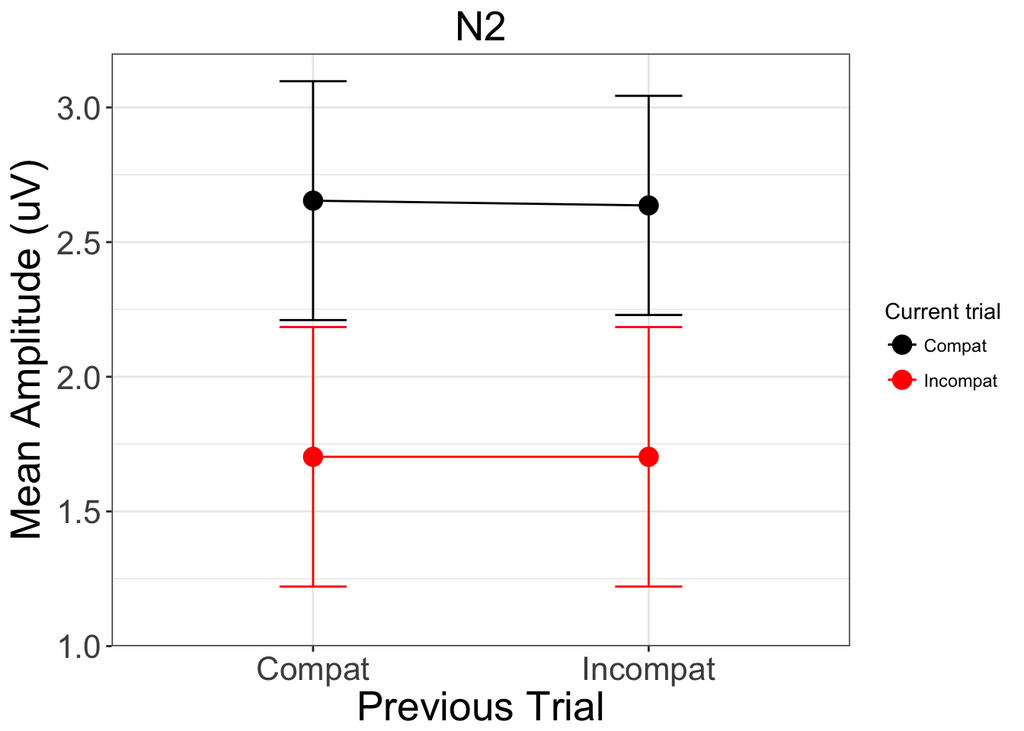

*Current and Previous are effect coded.* Uses trial-level data to test (rather than individual averages). Doesn’t include Trial in model.

**Random effects:**

```
##  Groups            Name             Std.Dev. Corr
##  Electrode:Subject (Intercept)      1.48212
##  Subject           (Intercept)      2.54974
##                    Current          0.47945   0.274
##                    Previous         0.27737  -0.374 -0.050
##                    Current:Previous 0.34719   0.412  0.217 -0.167
##  Residual                           9.33913
```

**Fixed effects:**

```
##                  Estimate Std. Error     df t value Pr(>|t|)
## (Intercept)         2.257      0.433 35.019   5.207    0.000
## Current            -0.392      0.083 34.613  -4.746    0.000
## Previous            0.078      0.051 34.035   1.530    0.135
## Current:Previous    0.080      0.062 34.410   1.297    0.203
```

### 2. Looking at change over course of task

**This includes all data points, *not* averaged across subject or electrode.**

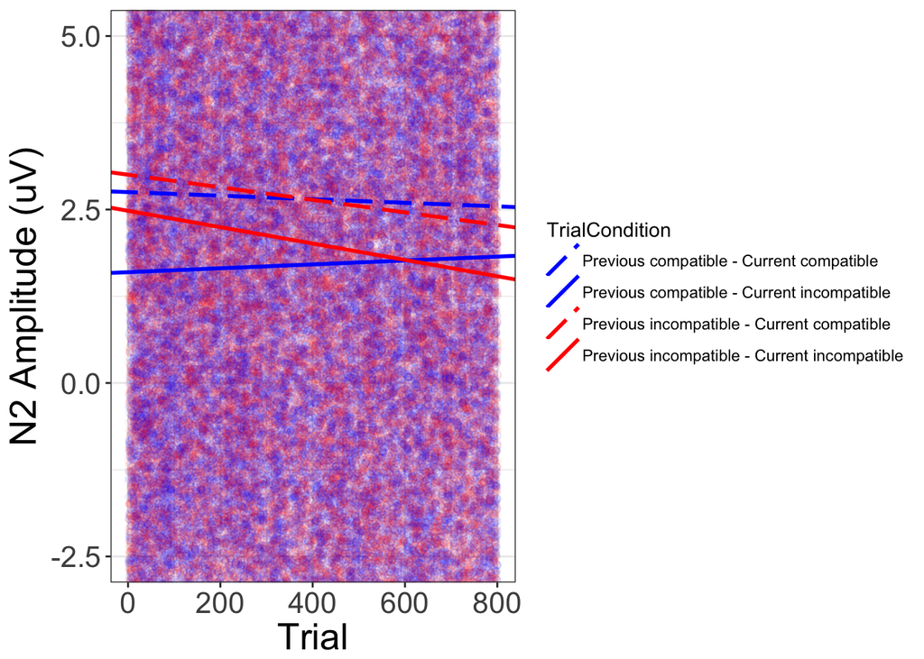

##### Simple slopes

Trial is scaled to range from 0 to 8 (instead of 1 to 800) so that the betas associated with trial are a little bigger (but significance testing is unaffected by linear scaling, so the test statistics and p values will be the same as if we used the unscaled Trial variable).

```
##   Estimate     SE ci95_lower ci95_upper  Current Previous      Color
## 1  -0.0257 0.0172   -0.06007    0.00867   Compat   Compat  dark blue
## 2  -0.0906 0.0180   -0.12648   -0.05464   Compat Incompat   dark red
## 3   0.0281 0.0181   -0.00803    0.06422 Incompat   Compat light blue
## 4  -0.1180 0.0187   -0.15538   -0.08065 Incompat Incompat  light red
```

#### Beginning of experiment

The intercept and slopes of current and previous trial condition are allowed to vary by subject. The intercept is allowed to vary by electrode nested within subject.

Trial is scaled to range from 0 to 8.

Categorical variables are effect coded.

**Random effects:**

```
##  Groups            Name             Std.Dev. Corr
##  Electrode:Subject (Intercept)      1.48214
##  Subject           (Intercept)      2.54940
##                    Current          0.47984   0.276
##                    Previous         0.27653  -0.376 -0.039
##                    Current:Previous 0.34679   0.412  0.220 -0.163
##  Residual                           9.33763
```

**Fixed effects:**

```
##                  Estimate Std. Error     df t value Pr(>|t|)
## (Intercept)         2.457      0.435 35.476   5.651    0.000
## Current            -0.418      0.090 48.121  -4.659    0.000
## Previous            0.283      0.062 74.368   4.602    0.000
## Current:Previous    0.158      0.071 60.342   2.238    0.029
```

```
##                              Estimate Std. Error       df t value Pr(>|t|)
## Trial.begin                    -0.052      0.009 204280.8  -5.733    0.000
## Current:Trial.begin             0.007      0.009 204263.8   0.733    0.464
## Previous:Trial.begin           -0.053      0.009 204140.6  -5.867    0.000
## Current:Previous:Trial.begin   -0.020      0.009 204234.5  -2.259    0.024
```

**Marginal means:**  
Error bars represent standard error.

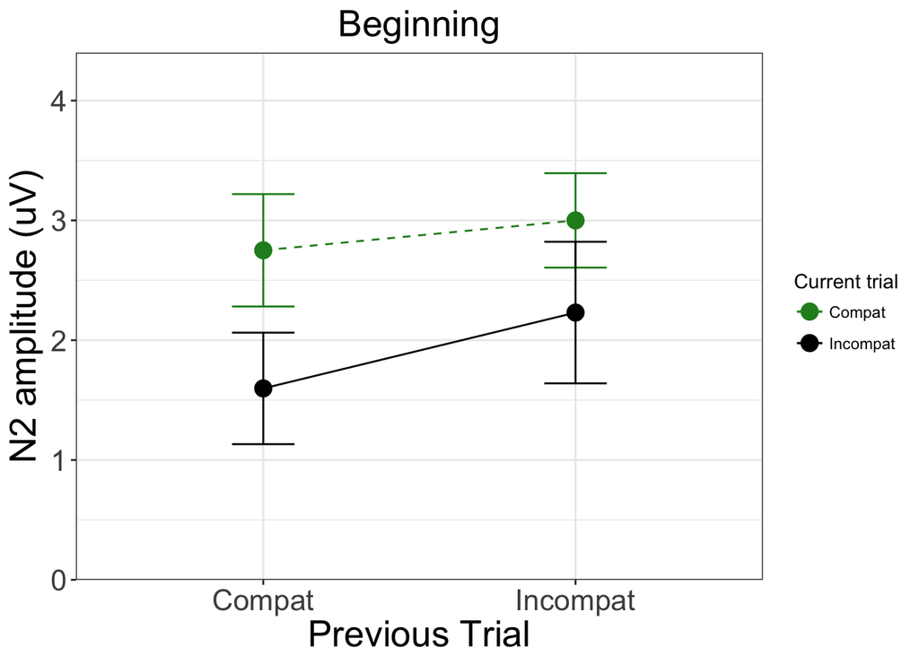

#### Middle of experiment

Trial is shifted so that trial ranges from -4 to 4.  
*Just the fixed effects of Current and Previous are shown, the random effects and fixed effects of any Trial interactions will be the same as the first model.*

**Fixed effects:**

```
##                  Estimate Std. Error     df t value Pr(>|t|)
## (Intercept)         2.251      0.433 35.025   5.194    0.000
## Current            -0.392      0.083 34.621  -4.740    0.000
## Previous            0.072      0.051 34.047   1.425    0.163
## Current:Previous    0.077      0.061 34.429   1.253    0.218
```

**Marginal means:**  
Error bars represent standard error.

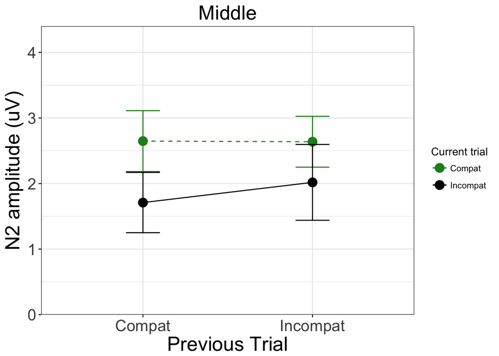

#### End of experiment

Trial is shifted so that trial ranges from -8 to 0.  
*Just the fixed effects of Current and Previous are shown, the random effects and fixed effects of any Trial interactions will be the same as the first model.*

**Fixed effects:**

```
##                  Estimate Std. Error     df t value Pr(>|t|)
## (Intercept)         2.045      0.435 35.547   4.701    0.000
## Current            -0.365      0.091 49.808  -4.037    0.000
## Previous           -0.139      0.063 79.841  -2.218    0.029
## Current:Previous   -0.004      0.072 63.729  -0.059    0.953
```

**Marginal means:**  
Error bars represent standard error.

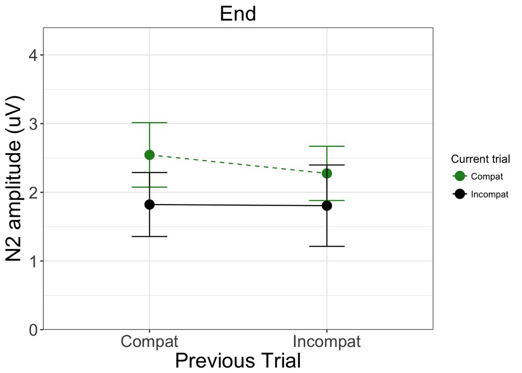